# Impact de la publicité multi-canal sur les ventes

### VI.3 Détection des outliers via la distance de Cook

La distance de Cook mesure l’influence d’une observation sur l’ensemble du modèle :

$$D_i = \frac{\sum_{j=1}^{n} (\hat{Y}_j -
\hat{Y}_{j(i)})^2}{p \cdot \hat{\sigma}^2}$$
Une règle générale pour identifier les observations influentes :
$$D_i > \frac{4}{n}$$
où :

- $D_i$ est la distance de Cook pour l’observation $i$,
- $\hat{Y}_j$ est la prédiction avec tous les points,
- $\hat{Y}_{j(i)}$ est la prédiction sans l’observation $i$,
- $p$ est le nombre de paramètres du modèle,
- $\hat{\sigma}^2$ est la variance des résidus.

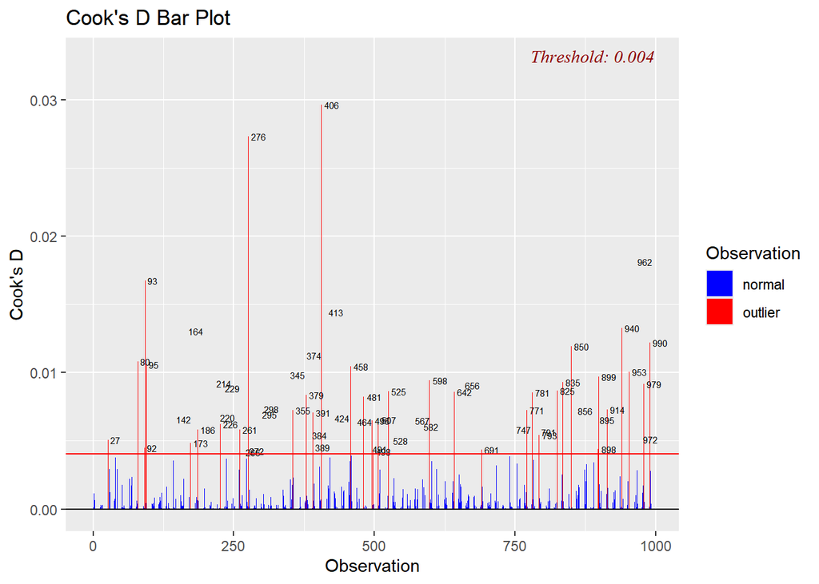

```
##  27  80  92  93  95 142 164 173 186 214 220 226 229 261 266 272 276 295 298 345
##  27  80  92  93  95 142 164 173 186 214 220 226 229 261 266 272 276 295 298 345
## 355 374 379 384 389 391 406 413 424 458 464 481 491 496 498 507 525 528 567 582
## 355 374 379 384 389 391 406 413 424 458 464 481 491 496 498 507 525 528 567 582
## 598 642 656 691 747 771 781 791 793 825 835 850 856 895 898 899 914 940 953 962
## 598 642 656 691 747 771 781 791 793 825 835 850 856 895 898 899 914 940 953 962
## 972 979 990
## 972 979 990
```

Les points qui dépassent la ligne rouge ont un effet disproportionné sur la régression. Ces points doivent être examinés individuellement pour voir s’ils sont des valeurs aberrantes ou des observations influentes.

### VI.4 Analyse des DFBETAS (Influence sur les coefficients)

DFBETAS (Difference in Betas) mesure l’impact d’une observation sur un coefficient de régression spécifique.
$$DFBETAS_{ij} = \frac{\beta_j - \beta_{j(i)}}{s_{(i)} \sqrt{C_{jj}}}$$
où :

- $\beta_j$ est le coefficient estimé avec tous les points,
- $\beta_{j(i)}$ est le coefficient estimé sans l’observation $i$,
- $C_{jj}$ est l’élément diagonal de la matrice $(X^T X)^{-1}$. Une valeur $|DFBETAS_{ij}| > 2 / \sqrt{n}$ indique une forte influence.

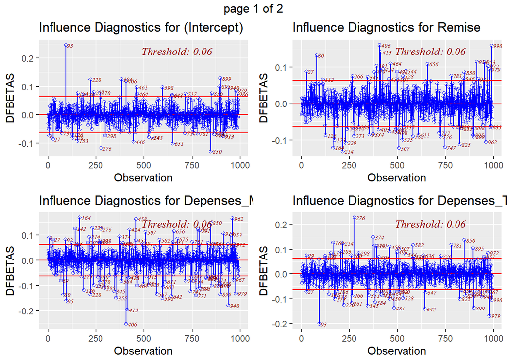

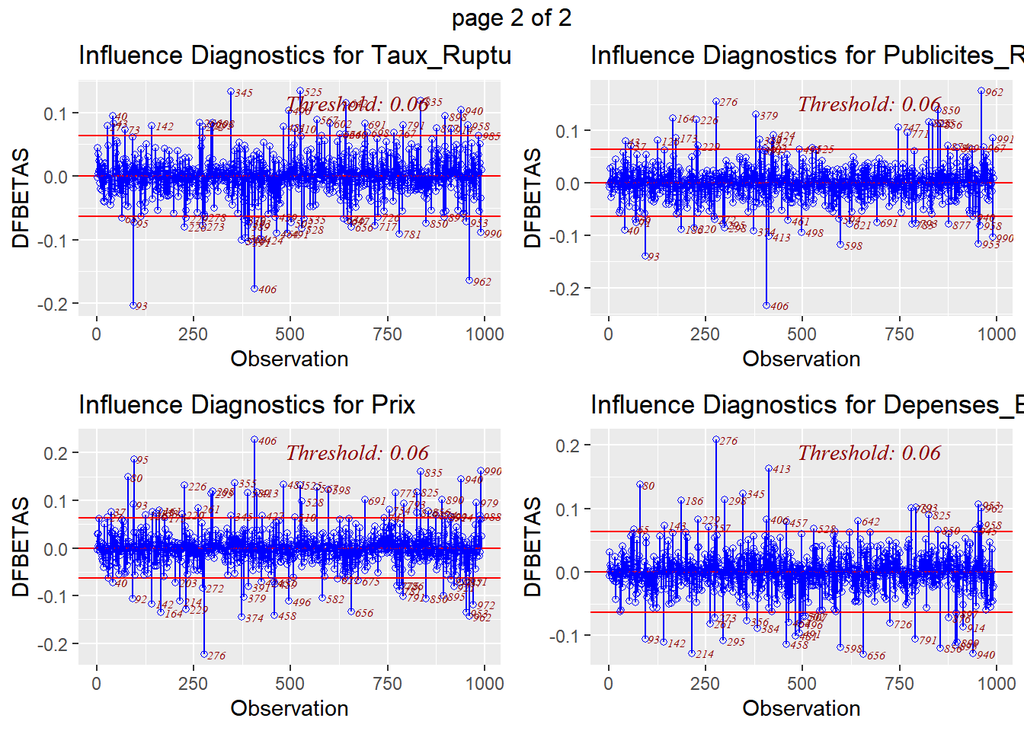

```
## Nombre d'observations influentes selon DFBETAS : 158
```

- De nombreuses observations influencent au moins un coefficient du modèle.
- La liste des indices influents est assez longue, ce qui signifie qu’il y a plusieurs valeurs qui affectent les estimations des coefficients.
- Les points les plus élevés dans le graphique doivent être examinés, car ils ont un effet important sur les paramètres du modèle.

### VI.5 Analyse des DFFITS (Influence sur les prédictions)

DFFITS (Difference in Fits) indique si une observation change fortement la valeur prédite du modèle.

$$DFFITS_i = \frac{\hat{Y}_i -
\hat{Y}_{i(i)}}{s_{(i)} \sqrt{h_i}}$$
où :

- $\hat{Y}_i$ est la prédiction avec tous les points,
- $\hat{Y}_{i(i)}$ est la prédiction sans l’observation $i$.

Une observation est considérée comme influente si :
$$|DFFITS_i| > 2 \frac{\sqrt{p}}{\sqrt{n}}$$

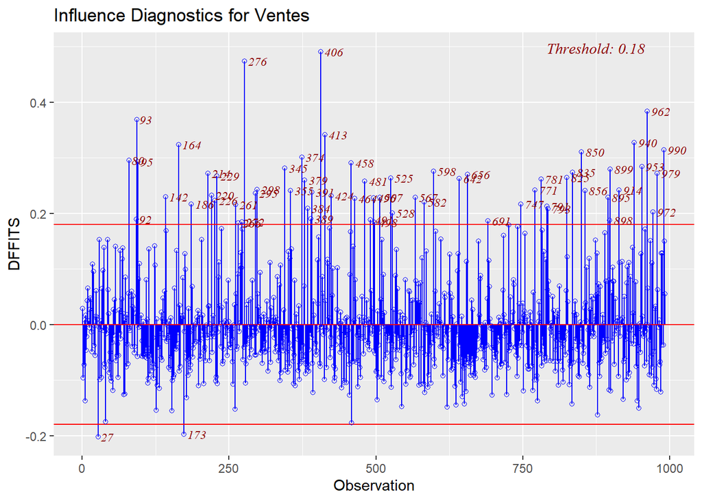

```
## Nombre d'observations influentes selon DFFITS : 73
```

- Les observations influentes selon DFFITS sont celles qui changent significativement la valeur prédite.
- Certaines observations apparaissent dans les deux listes (DFBETAS & DFFITS), ce qui indique qu’elles affectent à la fois les coefficients et les prédictions.
- Les points au-dessus de la ligne rouge dans le graphique DFFITS sont ceux qui ont le plus grand impact sur les valeurs prédites.

### **Resumé des influences**

| Critère | Nombre |
| --- | --- |
| Outliers (Résidus Studentisés > 2) | 61 |
| Outliers Sévères (Résidus Studentisés > 3) | 10 |
| Observations Influentes (DFBETAS) | 158 |
| Observations Influentes (DFFITS) | 73 |

### **Graphique d’influence**

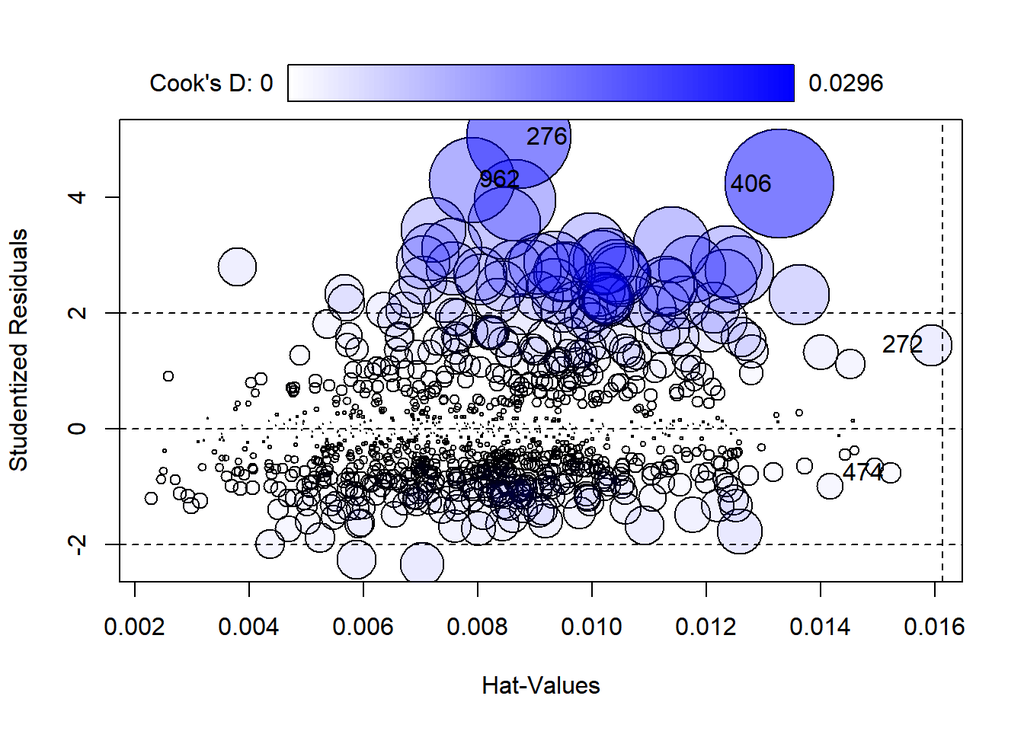

|  | StudRes | Hat | CookD |
| --- | --- | --- | --- |
| 272 | 1.4501153 | 0.015928739 | 0.004249946 |
| 276 | 5.0472564 | 0.008723734 | 0.027343777 |
| 406 | 4.2333154 | 0.013278439 | 0.029635958 |
| 474 | -0.7609882 | 0.015229419 | 0.001119954 |
| 962 | 4.3065587 | 0.007894521 | 0.018124361 |

### VI.6 Suppression des valeurs extrêmes et création du nouveau modèle

Suite à la visualisation de nos valeurs extrême, on peut créer un nouveau modèle en les supprimants afin de voir si il est possible de faire une meilleure étude de nos données.

**Modèle Initial**

```
##
## Call:
## lm(formula = Ventes ~ ., data = base)
##
## Residuals:
##     Min      1Q  Median      3Q     Max
## -7339.0 -2138.2  -559.3  1357.2 15604.7
##
## Coefficients:
##                      Estimate Std. Error  t value Pr(>|t|)
## (Intercept)         1.254e+05  4.685e+02  267.625  < 2e-16 ***
## Depenses_Magasin    2.875e+03  5.745e+00  500.406  < 2e-16 ***
## Remise              3.919e+03  6.879e+02    5.696 1.62e-08 ***
## Depenses_TV         5.890e+02  1.751e+00  336.410  < 2e-16 ***
## Taux_Rupture_Stock -1.357e+04  3.490e+02  -38.896  < 2e-16 ***
## Prix               -6.480e+03  1.150e+01 -563.633  < 2e-16 ***
## Publicites_Radio    6.234e-02  1.135e-01    0.549    0.583
## Depenses_En_Ligne   6.712e-02  1.080e-01    0.622    0.534
## ---
## Signif. codes:  0 '***' 0.001 '**' 0.01 '*' 0.05 '.' 0.1 ' ' 1
##
## Residual standard error: 3144 on 984 degrees of freedom
## Multiple R-squared:  0.9985, Adjusted R-squared:  0.9985
## F-statistic: 9.477e+04 on 7 and 984 DF,  p-value: < 2.2e-16
```

**Modèle sans Outliers (DFBETAS)**

```
##
## Call:
## lm(formula = Ventes ~ ., data = base_sans_dfbetas)
##
## Residuals:
##     Min      1Q  Median      3Q     Max
## -4455.3 -1377.4  -109.7  1171.5  5482.5
##
## Coefficients:
##                      Estimate Std. Error  t value Pr(>|t|)
## (Intercept)         1.245e+05  3.022e+02  411.890   <2e-16 ***
## Depenses_Magasin    2.890e+03  3.944e+00  732.761   <2e-16 ***
## Remise              4.046e+03  4.432e+02    9.129   <2e-16 ***
## Depenses_TV         5.910e+02  1.161e+00  508.886   <2e-16 ***
## Taux_Rupture_Stock -1.359e+04  2.255e+02  -60.273   <2e-16 ***
## Prix               -6.506e+03  7.806e+00 -833.400   <2e-16 ***
## Publicites_Radio    3.098e-02  7.278e-02    0.426    0.670
## Depenses_En_Ligne   6.228e-02  6.918e-02    0.900    0.368
## ---
## Signif. codes:  0 '***' 0.001 '**' 0.01 '*' 0.05 '.' 0.1 ' ' 1
##
## Residual standard error: 1852 on 826 degrees of freedom
## Multiple R-squared:  0.9993, Adjusted R-squared:  0.9993
## F-statistic: 1.663e+05 on 7 and 826 DF,  p-value: < 2.2e-16
```

### **Comparaison des modèles (avec et sans outlier)**

|  | Variable | Estimate..avec.outliers. | Std..Error..avec.outliers. | Estimate..Sans.outliers. | Std..Error..Sans.outliers. |
| --- | --- | --- | --- | --- | --- |
| (Intercept) | (Intercept) | 1.253787e+05 | 468.4857477 | 1.244869e+05 | 302.2333318 |
| Depenses_Magasin | Depenses_Magasin | 2.875053e+03 | 5.7454375 | 2.889688e+03 | 3.9435589 |
| Remise | Remise | 3.918554e+03 | 687.9435707 | 4.045521e+03 | 443.1527666 |
| Depenses_TV | Depenses_TV | 5.889906e+02 | 1.7508112 | 5.910017e+02 | 1.1613638 |
| Taux_Rupture_Stock | Taux_Rupture_Stock | -1.357312e+04 | 348.9574149 | -1.359020e+04 | 225.4764956 |
| Prix | Prix | -6.479546e+03 | 11.4960443 | -6.505530e+03 | 7.8060104 |
| Publicites_Radio | Publicites_Radio | 6.234050e-02 | 0.1134956 | 3.098500e-02 | 0.0727764 |
| Depenses_En_Ligne | Depenses_En_Ligne | 6.711730e-02 | 0.1079608 | 6.228050e-02 | 0.0691782 |

La suppression des outliers n’a pas drastiquement changé le modèle. Les variables Publicites_Radio, Depenses_En_Ligne restent non significatives, et pourraient être retirées pour optimiser le modèle.

## VII. Qualité d’ajustement du modèle

## VII.1 Analyse de la multicolinéarité

### Variance Inflation Factor (VIF)

Le Variance Inflation Factor (VIF) mesure dans quelle mesure la variance d’un coefficient de régression est augmentée à cause de la colinéarité avec les autres variables explicatives. Une valeur élevée indique une forte multicolinéarité.
$$\text{VIF}_j = \frac{1}{1 - R_j^2}$$

où $R_j^2$ est le coefficient de détermination obtenu en régressant la variable $X_j$ sur toutes les autres variables explicatives du modèle.

```
##   Depenses_Magasin             Remise        Depenses_TV Taux_Rupture_Stock
##           1.012931           1.002586           1.002800           1.004463
##               Prix   Publicites_Radio  Depenses_En_Ligne
##           1.006664           1.012642           1.005394
```

Toutes les valeurs du VIF sont inférieur à 2, ce qui indique une faible corrélation entre les variables explicatives. Le modèle est bien spécifié, et la multicolinéarité n’a pas d’impact négatif sur les estimations des coefficients.

### Tolérance

La tolérance est l’inverse du VIF et représente la proportion de variance d’une variable qui n’est pas expliquée par les autres variables du modèle.

$$\text{Tolérance}_j = \frac{1}{\text{VIF}_j} = 1 - R_j^2$$

```
##   Depenses_Magasin             Remise        Depenses_TV Taux_Rupture_Stock
##          0.9872345          0.9974209          0.9972077          0.9955569
##               Prix   Publicites_Radio  Depenses_En_Ligne
##          0.9933801          0.9875160          0.9946350
```

Toutes les valeurs de tolérance sont proches de 1, indiquant que chaque variable a une faible corrélation avec les autres. Cela signifie que le modèle est bien spécifié et que les coefficients de régression sont fiables et interprétables.

## VII.2 Sélection du modèle selon le Critère AIC

L’Akaike Information Criterion (AIC) est une mesure utilisée pour comparer différents modèles statistiques tout en prenant en compte à la fois la **qualité de l’ajustement** et **la complexité du modèle.**

L’AIC est défini comme :

$$AIC = -2 \ln(L) + 2 (p + 1)$$

où : - L est la vraisemblance du modèle, - p est le nombre de paramètres estimés. - Plus l’AIC est faible, meilleur est le modèle.

### AIC descendante (Backward)

On part d’un modele complet. A chaque etape, on elimine la variable sans laquelle, le modele a un AIC le plus faible.

```
## Start:  AIC=15985.41
## Ventes ~ Depenses_Magasin + Remise + Depenses_TV + Taux_Rupture_Stock +
##     Prix + Publicites_Radio + Depenses_En_Ligne
##
##                      Df  Sum of Sq        RSS   AIC
## - Publicites_Radio    1 2.9816e+06 9.7275e+09 15984
## - Depenses_En_Ligne   1 3.8195e+06 9.7284e+09 15984
## <none>                             9.7245e+09 15985
## - Remise              1 3.2064e+08 1.0045e+10 16016
## - Taux_Rupture_Stock  1 1.4952e+10 2.4676e+10 16907
## - Depenses_TV         1 1.1184e+12 1.1282e+12 20699
## - Depenses_Magasin    1 2.4747e+12 2.4844e+12 21482
## - Prix                1 3.1395e+12 3.1493e+12 21717
##
## Step:  AIC=15983.71
## Ventes ~ Depenses_Magasin + Remise + Depenses_TV + Taux_Rupture_Stock +
##     Prix + Depenses_En_Ligne
##
##                      Df  Sum of Sq        RSS   AIC
## - Depenses_En_Ligne   1 4.1555e+06 9.7317e+09 15982
## <none>                             9.7275e+09 15984
## - Remise              1 3.2067e+08 1.0048e+10 16014
## - Taux_Rupture_Stock  1 1.4950e+10 2.4678e+10 16905
## - Depenses_TV         1 1.1184e+12 1.1282e+12 20697
## - Depenses_Magasin    1 2.4930e+12 2.5027e+12 21488
## - Prix                1 3.1478e+12 3.1576e+12 21718
##
## Step:  AIC=15982.14
## Ventes ~ Depenses_Magasin + Remise + Depenses_TV + Taux_Rupture_Stock +
##     Prix
##
##                      Df  Sum of Sq        RSS   AIC
## <none>                             9.7317e+09 15982
## - Remise              1 3.1850e+08 1.0050e+10 16012
## - Taux_Rupture_Stock  1 1.4953e+10 2.4685e+10 16904
## - Depenses_TV         1 1.1187e+12 1.1284e+12 20695
## - Depenses_Magasin    1 2.4964e+12 2.5061e+12 21487
## - Prix                1 3.1498e+12 3.1595e+12 21717
```

```
##
## Call:
## lm(formula = Ventes ~ Depenses_Magasin + Remise + Depenses_TV +
##     Taux_Rupture_Stock + Prix, data = base)
##
## Residuals:
##    Min     1Q Median     3Q    Max
##  -7369  -2131   -557   1332  15745
##
## Coefficients:
##                      Estimate Std. Error  t value Pr(>|t|)
## (Intercept)        125592.793    393.810  318.917  < 2e-16 ***
## Depenses_Magasin     2874.911      5.716  502.922  < 2e-16 ***
## Remise               3902.999    687.071    5.681 1.77e-08 ***
## Depenses_TV           589.001      1.750  336.661  < 2e-16 ***
## Taux_Rupture_Stock -13573.577    348.725  -38.923  < 2e-16 ***
## Prix                -6480.041     11.471 -564.919  < 2e-16 ***
## ---
## Signif. codes:  0 '***' 0.001 '**' 0.01 '*' 0.05 '.' 0.1 ' ' 1
##
## Residual standard error: 3142 on 986 degrees of freedom
## Multiple R-squared:  0.9985, Adjusted R-squared:  0.9985
## F-statistic: 1.329e+05 on 5 and 986 DF,  p-value: < 2.2e-16
```

### AIC Ascendante (Forward)

On demarre avec une constance, de la forme
$$Y = b$$
.

A chaque etape, le procede ajoute la variable avec laquelle le modele a un AIC le plus faible.

```
## Start:  AIC=22434.29
## Ventes ~ 1
##
##                      Df  Sum of Sq        RSS   AIC
## + Prix                1 2.9772e+12 3.5888e+12 21837
## + Depenses_Magasin    1 2.1914e+12 4.3746e+12 22034
## + Depenses_TV         1 1.1217e+12 5.4442e+12 22250
## + Taux_Rupture_Stock  1 3.4450e+10 6.5315e+12 22431
## <none>                             6.5660e+12 22434
## + Depenses_En_Ligne   1 1.1796e+10 6.5542e+12 22435
## + Publicites_Radio    1 1.5495e+09 6.5644e+12 22436
## + Remise              1 7.9422e+08 6.5652e+12 22436
##
## Step:  AIC=21837.03
## Ventes ~ Prix
##
##                      Df  Sum of Sq        RSS   AIC
## + Depenses_Magasin    1 2.4317e+12 1.1571e+12 20716
## + Depenses_TV         1 1.0729e+12 2.5159e+12 21487
## + Publicites_Radio    1 1.8109e+10 3.5707e+12 21834
## + Taux_Rupture_Stock  1 1.4950e+10 3.5738e+12 21835
## <none>                             3.5888e+12 21837
## + Depenses_En_Ligne   1 4.7596e+09 3.5840e+12 21838
## + Remise              1 2.4933e+09 3.5863e+12 21838
##
## Step:  AIC=20716.18
## Ventes ~ Prix + Depenses_Magasin
##
##                      Df  Sum of Sq        RSS   AIC
## + Depenses_TV         1 1.1320e+12 2.5070e+10 16917
## + Taux_Rupture_Stock  1 2.8682e+10 1.1284e+12 20693
## <none>                             1.1571e+12 20716
## + Depenses_En_Ligne   1 2.3854e+08 1.1568e+12 20718
## + Remise              1 3.3787e+07 1.1570e+12 20718
## + Publicites_Radio    1 3.9481e+06 1.1571e+12 20718
##
## Step:  AIC=16916.85
## Ventes ~ Prix + Depenses_Magasin + Depenses_TV
##
##                      Df  Sum of Sq        RSS   AIC
```

[output cut: 8 more lines]

```
##
##                     Df Sum of Sq        RSS   AIC
## + Remise             1 318496669 9.7317e+09 15982
## <none>                           1.0050e+10 16012
## + Publicites_Radio   1   3237731 1.0047e+10 16014
## + Depenses_En_Ligne  1   1983585 1.0048e+10 16014
##
## Step:  AIC=15982.14
## Ventes ~ Prix + Depenses_Magasin + Depenses_TV + Taux_Rupture_Stock +
##     Remise
##
##                     Df Sum of Sq        RSS   AIC
## <none>                           9731676469 15982
## + Depenses_En_Ligne  1   4155507 9727520962 15984
## + Publicites_Radio   1   3317625 9728358844 15984
```

```
##
## Call:
## lm(formula = Ventes ~ Prix + Depenses_Magasin + Depenses_TV +
##     Taux_Rupture_Stock + Remise, data = base)
##
## Residuals:
##    Min     1Q Median     3Q    Max
##  -7369  -2131   -557   1332  15745
##
## Coefficients:
##                      Estimate Std. Error  t value Pr(>|t|)
## (Intercept)        125592.793    393.810  318.917  < 2e-16 ***
## Prix                -6480.041     11.471 -564.919  < 2e-16 ***
## Depenses_Magasin     2874.911      5.716  502.922  < 2e-16 ***
## Depenses_TV           589.001      1.750  336.661  < 2e-16 ***
## Taux_Rupture_Stock -13573.577    348.725  -38.923  < 2e-16 ***
## Remise               3902.999    687.071    5.681 1.77e-08 ***
## ---
## Signif. codes:  0 '***' 0.001 '**' 0.01 '*' 0.05 '.' 0.1 ' ' 1
##
## Residual standard error: 3142 on 986 degrees of freedom
## Multiple R-squared:  0.9985, Adjusted R-squared:  0.9985
## F-statistic: 1.329e+05 on 5 and 986 DF,  p-value: < 2.2e-16
```

### AIC Mixte (Forward + Backward)

Combine les deux méthodes : on ajoute les variables pertinentes et on en retire celles devenues inutiles.

```
## Start:  AIC=15985.41
## Ventes ~ Depenses_Magasin + Remise + Depenses_TV + Taux_Rupture_Stock +
##     Prix + Publicites_Radio + Depenses_En_Ligne
##
##                      Df  Sum of Sq        RSS   AIC
## - Publicites_Radio    1 2.9816e+06 9.7275e+09 15984
## - Depenses_En_Ligne   1 3.8195e+06 9.7284e+09 15984
## <none>                             9.7245e+09 15985
## - Remise              1 3.2064e+08 1.0045e+10 16016
## - Taux_Rupture_Stock  1 1.4952e+10 2.4676e+10 16907
## - Depenses_TV         1 1.1184e+12 1.1282e+12 20699
## - Depenses_Magasin    1 2.4747e+12 2.4844e+12 21482
## - Prix                1 3.1395e+12 3.1493e+12 21717
##
## Step:  AIC=15983.71
## Ventes ~ Depenses_Magasin + Remise + Depenses_TV + Taux_Rupture_Stock +
##     Prix + Depenses_En_Ligne
##
##                      Df  Sum of Sq        RSS   AIC
## - Depenses_En_Ligne   1 4.1555e+06 9.7317e+09 15982
## <none>                             9.7275e+09 15984
## + Publicites_Radio    1 2.9816e+06 9.7245e+09 15985
## - Remise              1 3.2067e+08 1.0048e+10 16014
## - Taux_Rupture_Stock  1 1.4950e+10 2.4678e+10 16905
## - Depenses_TV         1 1.1184e+12 1.1282e+12 20697
## - Depenses_Magasin    1 2.4930e+12 2.5027e+12 21488
## - Prix                1 3.1478e+12 3.1576e+12 21718
##
## Step:  AIC=15982.14
## Ventes ~ Depenses_Magasin + Remise + Depenses_TV + Taux_Rupture_Stock +
##     Prix
##
##                      Df  Sum of Sq        RSS   AIC
## <none>                             9.7317e+09 15982
## + Depenses_En_Ligne   1 4.1555e+06 9.7275e+09 15984
## + Publicites_Radio    1 3.3176e+06 9.7284e+09 15984
## - Remise              1 3.1850e+08 1.0050e+10 16012
## - Taux_Rupture_Stock  1 1.4953e+10 2.4685e+10 16904
## - Depenses_TV         1 1.1187e+12 1.1284e+12 20695
## - Depenses_Magasin    1 2.4964e+12 2.5061e+12 21487
## - Prix                1 3.1498e+12 3.1595e+12 21717
```

```
##
## Call:
## lm(formula = Ventes ~ Depenses_Magasin + Remise + Depenses_TV +
##     Taux_Rupture_Stock + Prix, data = base)
##
## Residuals:
##    Min     1Q Median     3Q    Max
##  -7369  -2131   -557   1332  15745
##
## Coefficients:
##                      Estimate Std. Error  t value Pr(>|t|)
## (Intercept)        125592.793    393.810  318.917  < 2e-16 ***
## Depenses_Magasin     2874.911      5.716  502.922  < 2e-16 ***
## Remise               3902.999    687.071    5.681 1.77e-08 ***
## Depenses_TV           589.001      1.750  336.661  < 2e-16 ***
## Taux_Rupture_Stock -13573.577    348.725  -38.923  < 2e-16 ***
## Prix                -6480.041     11.471 -564.919  < 2e-16 ***
## ---
## Signif. codes:  0 '***' 0.001 '**' 0.01 '*' 0.05 '.' 0.1 ' ' 1
##
## Residual standard error: 3142 on 986 degrees of freedom
## Multiple R-squared:  0.9985, Adjusted R-squared:  0.9985
## F-statistic: 1.329e+05 on 5 and 986 DF,  p-value: < 2.2e-16
```

**Conclusion**

Le modèle présentant l’AIC le plus bas constitue le meilleur compromis entre précision et simplicité. Dans notre cas, les différentes méthodes de sélection basées sur le critère AIC aboutissent à la même valeur.

## VII.3 Sélection du modèle selon le Critère BIC

Le critère d’information bayésien (BIC) est une mesure statistique utilisée pour la sélection de modèles parmi un ensemble fini de modèles. Le BIC pénalise plus fortement que AIC, car log(n) croit avec n, rendant les modèles complexes moins attractif lorsque l’échantillon est grand.

Sa **définition formelle** est la suivante :

$$BIC = -2 \ln(L) + (p +1)
\ln(n)$$

- L : Vraisemblance maximale du modèle
- p : Nombre de paramètres estimés par le modèle
- n : Taille de l’échantillon (nombre d’observations)

**Formule spécifique à la régression linéaire** : Pour un modèle de régression linéaire, le BIC peut être exprimé en fonction de l’erreur quadratique moyenne(MSE) :

$$BIC = n \ln(MSE) + (p+1) \ln(n)$$
- n : Nombre d’observations.

- MSE : Mean Squared Error (Erreur Quadratique Moyenne) avec
  $$MSE = \frac{RSS}{n}$$
- p : Nombre de paramètres estimés dans le modèle, incluant l’intercept.

**Modèle sélectionné par BIC (Descendant)**

```
## lm(formula = Ventes ~ Depenses_Magasin + Remise + Depenses_TV +
##     Taux_Rupture_Stock + Prix, data = base)
```

**Modèle sélectionné par BIC (Ascendant)**

```
## lm(formula = Ventes ~ Prix + Depenses_Magasin + Depenses_TV +
##     Taux_Rupture_Stock + Remise, data = base)
```

**Modèle sélectionné par BIC** ***

```
## lm(formula = Ventes ~ Prix + Depenses_Magasin + Depenses_TV +
##     Taux_Rupture_Stock + Remise, data = base)
```

### **Comparaison des Modèles**

**Bilan pour l’AIC**

| Variable | Backward | Forward | Stepwise |
| --- | --- | --- | --- |
| Depenses_Magasin | O | O | O |
| Remise | O | O | O |
| Depenses_TV | O | O | O |
| Taux_Rupture_Stock | O | O | O |
| Prix | O | O | O |
| Publicites_Radio | X | X | X |
| Depenses_En_Ligne | X | X | X |

**Bilan pour le BIC**

| Variable | Backward | Forward | Stepwise |
| --- | --- | --- | --- |
| Depenses_Magasin | O | O | O |
| Remise | O | O | O |
| Depenses_TV | O | O | O |
| Taux_Rupture_Stock | O | O | O |
| Prix | O | O | O |
| Publicites_Radio | X | X | X |
| Depenses_En_Ligne | X | X | X |

Le modèle présentant le BIC le plus bas représente le meilleur équilibre entre précision et simplicité. Dans notre cas, toutes les méthodes de sélection basées sur le critère BIC aboutissent au même modèle optimal.

### Conclusion de l’AIC et BIC

Tandis que l’AIC privilégie la qualité d’ajustement en accordant plus de poids à la précision, le BIC favorise les modèles plus simples, en appliquant une pénalisation plus forte à la complexité.

Dans notre cas, les deux critères ont convergé vers le même modèle, excluant les variables Publicités_Radio et Dépenses_En_Ligne. Ce choix valide la pertinence du modèle simplifié, qui représente un compromis optimal entre performance prédictive et interprétabilité.

## VII.3 AIC ET BIC sans outliers(dfbetas)

```
## [1] " AIC avec DFBETAS : 18802.58"
```

```
## [1] " AIC sans DFBETAS : 14927.16"
```

```
## [1] " BIC avec DFBETAS : 18846.68"
```

```
## [1] " BIC sans DFBETAS : 14969.7"
```

La supression des outliers a considérablement améliorer l’AIC et le BIC. Donc, on décide de suprimer les ouliers et de garder le modèle sans dfbetas. De plus, la sélection du modèle nous permets de selectionner toutes les variable sauf **Publicites_Radio et Depenses_En_Ligne**.

### **Conclusion du Modèle de Régression Linéaire**

Nous concluons que le modèle de régression linéaire seul n’est pas suffisant pour expliquer le lien entre notre variables cible et nos variables explicatives. Afin d’explorer d’autres approches plus adaptées, nous allons nous orienter vers les modèles de régression généralisée (GLM), qui permettront de tester différentes distributions de la variable cible et d’adapter la fonction de lien en fonction de la nature des données.

L’objectif est de trouver un modèle plus performant et plus robuste, capable de mieux représenter les relations sous-jacentes aux données et d’améliorer la qualité des prédictions.

# PARTIE III: Modèle Linéaire Généralisé (GLM)

Le Modèle Linéaire Généralisé est une extension du modèle de régression linéaire qui permet d’analyser des variables dépendantes qui ne suivent pas une loi normale. Contrairement au modèle linéaire classique, le GLM permet d’utiliser :

- Une distribution adaptée à la nature des données (normale, binomiale, poisson, gamma…).
- Une fonction de lien pour relier la moyenne de la variable dépendante à une combinaison linéaire des prédicteurs.

**Structure mathématique du GLM**

la matrice design X est définie comme :
$$X =
\begin{bmatrix}
1 & x_{1,1} & \dots & x_{1,p} \\
\vdots & \vdots & \ddots & \vdots \\
1 & x_{n,1} & \dots & x_{n,p}
\end{bmatrix}$$
La fonction de densité de probabilité $f_{Y|X=x}$ de la variable aléatoire Y conditionnée à X = *x*

$$f_{Y|X=x}(y_i) = \exp\left( \frac{y_i \theta_i - b(\theta_i)}{a_i(\phi)}
+ c(y_i, \phi) \right)$$

où :

- $\theta$ est le paramètre naturel d’intérêt
- $\phi$ est le paramètre de nuisance (supposé connu)
- $a, b, c$ sont des fonctions connues

L’espérance et la variance sont définies par :

$$E[Y | X = x_i] = g^{-1}(\theta_i)$$

$$\text{Var}(Y | X = x_i) = b' (g(\mu_i)) \phi$$

Le modèle s’écrit alors : **$y_i = g^{-1}(X_i^T A) + \epsilon_i$** avec :$A = \theta$

Il existe différents modèles GLM. Pour l’application à tous ces modèles, il faut faire attention à l’indépendances des observations (et des erreurs), à l’absence de valeurs aberrantes et à l’absence de multicolinéarité excessive. Voici les différents types de modèles:

- Modèle GLM pour des variables qualitatives : modèle logistique binomial (quand on a des variables binaires)
- Modèle de poisson (quand on a des variable de comptage)
- Modèle GLM pour des variables continues : gaussien, distribution de Student, distribution beta ou distribution Gamma.

## I. Proposition du model linéaire généralisé

Notre variable cible étant strictement positive, nous utiliserons une distribution Gamma pour la modélisation. Afin d’optimiser la spécification du modèle, nous comparerons différentes fonctions de lien (inverse, log, identity) pour déterminer celle qui procure l’ajustement optimal aux données.

### Modèle gaussien avec link = log

```
##
## Call:
## glm(formula = Ventes ~ ., family = gaussian(link = "log"), data = base)
##
## Coefficients:
##                      Estimate Std. Error t value Pr(>|t|)
## (Intercept)         1.176e+01  1.568e-02 749.774  < 2e-16 ***
## Depenses_Magasin    1.481e-02  1.958e-04  75.617  < 2e-16 ***
## Remise              4.462e-02  2.116e-02   2.109   0.0352 *
## Depenses_TV         2.922e-03  5.640e-05  51.807  < 2e-16 ***
## Taux_Rupture_Stock -7.003e-02  1.088e-02  -6.438 1.89e-10 ***
## Prix               -3.401e-02  4.039e-04 -84.205  < 2e-16 ***
## Publicites_Radio   -3.846e-06  3.570e-06  -1.077   0.2815
## Depenses_En_Ligne  -1.014e-06  3.335e-06  -0.304   0.7612
## ---
## Signif. codes:  0 '***' 0.001 '**' 0.01 '*' 0.05 '.' 0.1 ' ' 1
##
## (Dispersion parameter for gaussian family taken to be 345131606)
##
##     Null deviance: 6.5660e+12  on 991  degrees of freedom
## Residual deviance: 3.3961e+11  on 984  degrees of freedom
## AIC: 22327
##
## Number of Fisher Scoring iterations: 6
```

### Modèle Gamma avec lien = identity

```
##
## Call:
## glm(formula = Ventes ~ ., family = Gamma(link = "identity"),
##     data = base)
##
## Coefficients:
##                      Estimate Std. Error  t value Pr(>|t|)
## (Intercept)         1.271e+05  5.896e+02  215.486  < 2e-16 ***
## Depenses_Magasin    2.664e+03  7.147e+00  372.668  < 2e-16 ***
## Remise              8.624e+03  7.387e+02   11.674  < 2e-16 ***
## Depenses_TV         5.571e+02  2.102e+00  265.041  < 2e-16 ***
## Taux_Rupture_Stock -1.355e+04  2.784e+02  -48.665  < 2e-16 ***
## Prix               -6.049e+03  1.526e+01 -396.332  < 2e-16 ***
## Publicites_Radio   -6.152e-01  1.052e-01   -5.847 6.79e-09 ***
## Depenses_En_Ligne  -4.161e-01  7.561e-02   -5.502 4.78e-08 ***
## ---
## Signif. codes:  0 '***' 0.001 '**' 0.01 '*' 0.05 '.' 0.1 ' ' 1
##
## (Dispersion parameter for Gamma family taken to be 0.001719501)
##
##     Null deviance: 321.9182  on 991  degrees of freedom
## Residual deviance:   1.7497  on 984  degrees of freedom
## AIC: 20132
##
## Number of Fisher Scoring iterations: 10
```

### Modèle Gamma avec lien inverse

```
##
## Call:
## glm(formula = Ventes ~ ., family = Gamma(link = "inverse"), data = base)
##
## Coefficients:
##                      Estimate Std. Error t value Pr(>|t|)
## (Intercept)         8.037e-06  2.176e-07  36.928   <2e-16 ***
## Depenses_Magasin   -8.448e-08  2.650e-09 -31.885   <2e-16 ***
## Remise             -4.992e-07  2.726e-07  -1.831   0.0674 .
## Depenses_TV        -1.560e-08  7.666e-10 -20.354   <2e-16 ***
## Taux_Rupture_Stock  3.257e-07  1.479e-07   2.202   0.0279 *
## Prix                1.988e-07  5.515e-09  36.051   <2e-16 ***
## Publicites_Radio    5.715e-11  4.700e-11   1.216   0.2243
## Depenses_En_Ligne   2.408e-11  4.356e-11   0.553   0.5806
## ---
## Signif. codes:  0 '***' 0.001 '**' 0.01 '*' 0.05 '.' 0.1 ' ' 1
##
## (Dispersion parameter for Gamma family taken to be 0.06547839)
##
##     Null deviance: 321.92  on 991  degrees of freedom
## Residual deviance: 115.44  on 984  degrees of freedom
## AIC: 24307
##
## Number of Fisher Scoring iterations: 4
```

### Modèle Gamma avec lien logarithmique

```
##
## Call:
## glm(formula = Ventes ~ ., family = Gamma(link = "log"), data = base)
##
## Coefficients:
##                      Estimate Std. Error t value Pr(>|t|)
## (Intercept)         1.160e+01  2.722e-02 426.114  < 2e-16 ***
## Depenses_Magasin    2.060e-02  3.338e-04  61.703  < 2e-16 ***
## Remise              2.750e-02  3.997e-02   0.688    0.492
## Depenses_TV         4.128e-03  1.017e-04  40.582  < 2e-16 ***
## Taux_Rupture_Stock -1.245e-01  2.027e-02  -6.143 1.17e-09 ***
## Prix               -4.549e-02  6.679e-04 -68.108  < 2e-16 ***
## Publicites_Radio   -7.642e-07  6.594e-06  -0.116    0.908
## Depenses_En_Ligne   5.165e-07  6.272e-06   0.082    0.934
## ---
## Signif. codes:  0 '***' 0.001 '**' 0.01 '*' 0.05 '.' 0.1 ' ' 1
##
## (Dispersion parameter for Gamma family taken to be 0.03335532)
##
##     Null deviance: 321.92  on 991  degrees of freedom
## Residual deviance:  53.21  on 984  degrees of freedom
## AIC: 23528
##
## Number of Fisher Scoring iterations: 7
```

## II. Comparaison des modèles

|  | AIC | BIC | RMSE |
| --- | --- | --- | --- |
| LM | 18802.58 | 18846.68 | 3130.968 |
| GLM (Gamma - Identity) | 20131.83 | 20175.93 | 6754.762 |
| GLM (Gamma - Inverse) | 24306.60 | 24350.70 | 60613.921 |
| GLM (Gamma - Log) | 23527.88 | 23571.98 | 39486.156 |
| GLM (Gaussien - Log) | 22327.29 | 22371.39 | 18502.575 |

Le modèle de regression linéaire à le BIC et l’AIC le plus faible donc on continue avec le modèle linéaire.

**Test de Vuong**

On va utiliser le test de vuong sur les deux modèles ayant l’AIC et le BIC le plus faible pour confirmer le choix de notre modèle final.

```
## nonnest2 has not been tested with all combinations of supported model classes.
```

```
##
## Model 1
##  Class: lm
##  Call: lm(formula = Ventes ~ ., data = base)
##
## Model 2
##  Class: glm
##  Call: glm(formula = Ventes ~ ., family = Gamma(link = "identity"), ...
##
## Variance test
##   H0: Model 1 and Model 2 are indistinguishable
##   H1: Model 1 and Model 2 are distinguishable
##     w2 = 2.970,   p = 2.26e-09
##
## Non-nested likelihood ratio test
##   H0: Model fits are equal for the focal population
##   H1A: Model 1 fits better than Model 2
##     z = 12.245,   p = <2e-16
##   H1B: Model 2 fits better than Model 1
##     z = 12.245,   p = 1
```

D’après le test de Vuong, le modèle linéaire est significativement meilleur que le GLM gamma(identity).

Pour améliorer la précision du modèle linéaire, nous allons transformer la variable cible avec le logarithme.

## III. Transformation de la variable cible

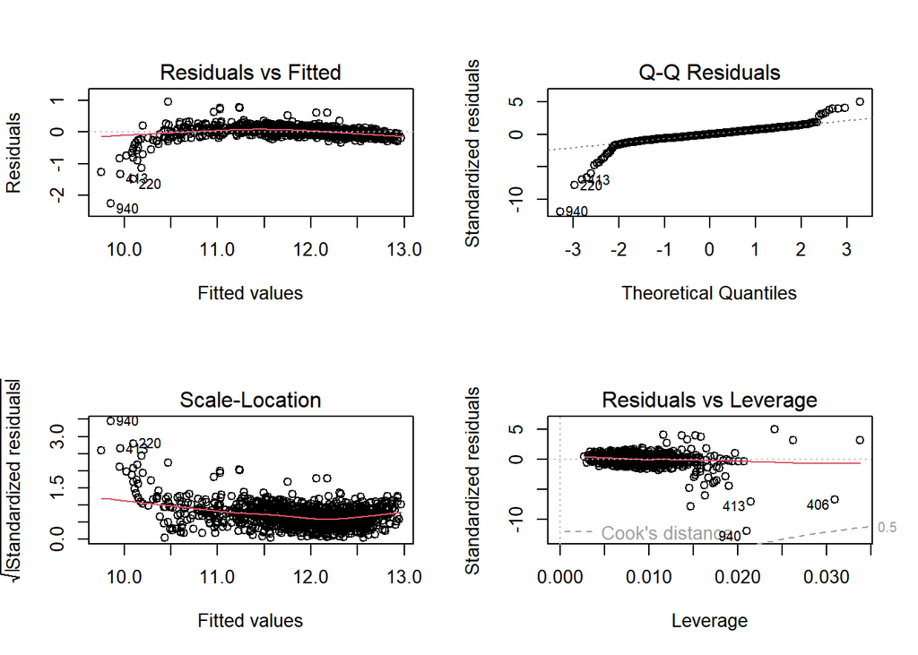

### III.1 Diagnoctic à postériori du nouveau modèle

Nous allons vérifier les hypothèses 1 et 5 du diagnostic à priori, à savoir la linéarité du modèle et la normalité des résidus.

### Linéarité du modèle

**Test de Ramsey Reset**

Hypotèses :

- $H_O$: Le modèle est linéaire
- $H_1$: Le modèle est non linéaire

```
##
##  RESET test
##
## data:  modele_lm_log
## RESET = 1788.3, df1 = 2, df2 = 981, p-value < 2.2e-16
```

**Test Tsay**

Hypotèses :

- $H_O$: Le modèle est linéaire
- $H_1$: Le modèle est non linéaire

```
##
## Call:
## lm(formula = res ~ poly(fitted_values, 2, raw = TRUE))
##
## Residuals:
##      Min       1Q   Median       3Q      Max
## -1.66022 -0.07596 -0.00372  0.07108  1.14238
##
## Coefficients:
##                                       Estimate Std. Error t value Pr(>|t|)
## (Intercept)                         -29.735834   1.267551  -23.46   <2e-16 ***
## poly(fitted_values, 2, raw = TRUE)1   5.130626   0.218275   23.50   <2e-16 ***
## poly(fitted_values, 2, raw = TRUE)2  -0.220538   0.009377  -23.52   <2e-16 ***
## ---
## Signif. codes:  0 '***' 0.001 '**' 0.01 '*' 0.05 '.' 0.1 ' ' 1
##
## Residual standard error: 0.1531 on 989 degrees of freedom
## Multiple R-squared:  0.3587, Adjusted R-squared:  0.3574
## F-statistic: 276.6 on 2 and 989 DF,  p-value: < 2.2e-16
```

Les deux tests n’ont pas permis de conclure sur la linéarité du modèle. ***

### Normalité du modèle

*Test de Shapiro-Wilk*

Hypothèses :

- $H_0$ : Le modèle suit une loi normale
- $H_1$ : Le modèle ne suit pas une loi normale

```
##
##  Shapiro-Wilk normality test
##
## data:  erreur
## W = 0.97132, p-value = 4.347e-13
```

*Test de Lilliefors*

Hypothèses :

- $H_0$: Le modèle suit une loi normale
- $H_1$ : Le modèle ne suit pas une loi normale.

```
## [1] "Lilliefors p-value: 5.35211950880887e-38"
```

Les deux tests n’ont pas permis de conclure sur la normalité du modèle.

## VI. Régression Polynomiale

Commme notre modèle avait la forme parabolique d’un polynome du second dégré, nous allons passer à la régression polynomiale afin de conclure.

```
##
## Call:
## lm(formula = Ventes ~ poly(Depenses_Magasin, 2, raw = TRUE) +
##     poly(Remise, 2, raw = TRUE) + poly(Depenses_TV, 2, raw = TRUE) +
##     poly(Taux_Rupture_Stock, 2, raw = TRUE) + poly(Prix, 2, raw = TRUE) +
##     poly(Publicites_Radio, 2, raw = TRUE) + poly(Depenses_En_Ligne,
##     2, raw = TRUE), data = base)
##
## Residuals:
##     Min      1Q  Median      3Q     Max
## -7684.8 -1993.0  -345.1  1583.0 14944.4
##
## Coefficients:
##                                            Estimate Std. Error  t value
## (Intercept)                               1.288e+05  7.362e+02  174.920
## poly(Depenses_Magasin, 2, raw = TRUE)1    2.731e+03  2.194e+01  124.474
## poly(Depenses_Magasin, 2, raw = TRUE)2    2.379e+00  3.537e-01    6.728
## poly(Remise, 2, raw = TRUE)1              9.724e+02  2.613e+03    0.372
## poly(Remise, 2, raw = TRUE)2              5.694e+03  5.064e+03    1.125
## poly(Depenses_TV, 2, raw = TRUE)1         5.757e+02  6.732e+00   85.510
## poly(Depenses_TV, 2, raw = TRUE)2         6.882e-02  3.284e-02    2.096
## poly(Taux_Rupture_Stock, 2, raw = TRUE)1 -1.270e+04  1.351e+03   -9.400
## poly(Taux_Rupture_Stock, 2, raw = TRUE)2 -7.572e+02  1.311e+03   -0.578
## poly(Prix, 2, raw = TRUE)1               -6.760e+03  4.390e+01 -153.988
## poly(Prix, 2, raw = TRUE)2                9.586e+00  1.435e+00    6.681
## poly(Publicites_Radio, 2, raw = TRUE)1    3.986e-01  4.466e-01    0.892
## poly(Publicites_Radio, 2, raw = TRUE)2   -1.125e-04  1.439e-04   -0.781
## poly(Depenses_En_Ligne, 2, raw = TRUE)1  -3.832e-01  4.190e-01   -0.915
## poly(Depenses_En_Ligne, 2, raw = TRUE)2   1.249e-04  1.263e-04    0.989
##                                          Pr(>|t|)
## (Intercept)                               < 2e-16 ***
## poly(Depenses_Magasin, 2, raw = TRUE)1    < 2e-16 ***
## poly(Depenses_Magasin, 2, raw = TRUE)2   2.93e-11 ***
## poly(Remise, 2, raw = TRUE)1               0.7099
## poly(Remise, 2, raw = TRUE)2               0.2611
## poly(Depenses_TV, 2, raw = TRUE)1         < 2e-16 ***
## poly(Depenses_TV, 2, raw = TRUE)2          0.0364 *
## poly(Taux_Rupture_Stock, 2, raw = TRUE)1  < 2e-16 ***
## poly(Taux_Rupture_Stock, 2, raw = TRUE)2   0.5637
## poly(Prix, 2, raw = TRUE)1                < 2e-16 ***
## poly(Prix, 2, raw = TRUE)2               3.98e-11 ***
## poly(Publicites_Radio, 2, raw = TRUE)1     0.3724
## poly(Publicites_Radio, 2, raw = TRUE)2     0.4347
## poly(Depenses_En_Ligne, 2, raw = TRUE)1    0.3607
## poly(Depenses_En_Ligne, 2, raw = TRUE)2    0.3227
## ---
## Signif. codes:  0 '***' 0.001 '**' 0.01 '*' 0.05 '.' 0.1 ' ' 1
##
## Residual standard error: 3010 on 977 degrees of freedom
## Multiple R-squared:  0.9987, Adjusted R-squared:  0.9986
## F-statistic: 5.171e+04 on 14 and 977 DF,  p-value: < 2.2e-16
```

Le modèle a sélectionné les variables les plus influentes : **Depenses_Magasin, Depenses_TV, Taux_Rupture_Stock et Prix** ont un impact fort sur les ventes.Parcontre les variables comme **Remise, Publicites_Radio et Depenses_En_Ligne** ne semblent pas avoir un impact significatif. Si on veut améliorer le modèle, on peut supprimer les variables non significatives/

```
##
## Call:
## lm(formula = Ventes ~ poly(Depenses_Magasin, 2, raw = TRUE) +
##     poly(Depenses_TV, 2, raw = TRUE) + poly(Taux_Rupture_Stock,
##     1, raw = TRUE) + poly(Prix, 2, raw = TRUE), data = base)
##
## Residuals:
##     Min      1Q  Median      3Q     Max
## -8526.9 -2024.6  -360.6  1514.0 14939.8
##
## Coefficients:
##                                           Estimate Std. Error  t value Pr(>|t|)
## (Intercept)                              1.297e+05  4.935e+02  262.852  < 2e-16
## poly(Depenses_Magasin, 2, raw = TRUE)1   2.731e+03  2.216e+01  123.256  < 2e-16
## poly(Depenses_Magasin, 2, raw = TRUE)2   2.398e+00  3.579e-01    6.701 3.47e-11
## poly(Depenses_TV, 2, raw = TRUE)1        5.746e+02  6.795e+00   84.571  < 2e-16
## poly(Depenses_TV, 2, raw = TRUE)2        7.339e-02  3.315e-02    2.214   0.0271
## poly(Taux_Rupture_Stock, 1, raw = TRUE) -1.347e+04  3.393e+02  -39.690  < 2e-16
## poly(Prix, 2, raw = TRUE)1              -6.757e+03  4.440e+01 -152.168  < 2e-16
## poly(Prix, 2, raw = TRUE)2               9.503e+00  1.451e+00    6.548 9.38e-11
##
## (Intercept)                             ***
## poly(Depenses_Magasin, 2, raw = TRUE)1  ***
## poly(Depenses_Magasin, 2, raw = TRUE)2  ***
## poly(Depenses_TV, 2, raw = TRUE)1       ***
## poly(Depenses_TV, 2, raw = TRUE)2       *
## poly(Taux_Rupture_Stock, 1, raw = TRUE) ***
## poly(Prix, 2, raw = TRUE)1              ***
## poly(Prix, 2, raw = TRUE)2              ***
## ---
## Signif. codes:  0 '***' 0.001 '**' 0.01 '*' 0.05 '.' 0.1 ' ' 1
##
## Residual standard error: 3055 on 984 degrees of freedom
## Multiple R-squared:  0.9986, Adjusted R-squared:  0.9986
## F-statistic: 1.004e+05 on 7 and 984 DF,  p-value: < 2.2e-16
```

Vérifions les hypothèses de linéarité du modèle et de normalité des résidus pour conclure.

### VI.1 Diagnoctic à postériori du nouveau modèle

Nous allons vérifier les hypothèses 1 et 5 du diagnostic à priori, à savoir la linéarité du modèle et la normalité des résidus.

### Linéarité du modèle

**Test de Ramsey Reset**

Hypotèses :

- $H_O$: Le modèle est linéaire
- $H_1$: Le modèle est non linéaire

```
##
##  RESET test
##
## data:  modele_poly_reduit
## RESET = 768.39, df1 = 2, df2 = 982, p-value < 2.2e-16
```

**Test Tsay**

Hypotèses :

- $H_O$: Le modèle est linéaire
- $H_1$: Le modèle est non linéaire

```
##
## Call:
## lm(formula = res ~ poly(fitted_values, 2, raw = TRUE))
##
## Residuals:
##     Min      1Q  Median      3Q     Max
## -7167.2 -1473.6   -19.2  1241.1 12073.0
##
## Coefficients:
##                                       Estimate Std. Error t value Pr(>|t|)
## (Intercept)                          6.509e+03  2.603e+02   25.01   <2e-16 ***
## poly(fitted_values, 2, raw = TRUE)1 -9.440e-02  3.102e-03  -30.43   <2e-16 ***
## poly(fitted_values, 2, raw = TRUE)2  2.687e-07  8.502e-09   31.61   <2e-16 ***
## ---
## Signif. codes:  0 '***' 0.001 '**' 0.01 '*' 0.05 '.' 0.1 ' ' 1
##
## Residual standard error: 2149 on 989 degrees of freedom
## Multiple R-squared:  0.5025, Adjusted R-squared:  0.5015
## F-statistic: 499.5 on 2 and 989 DF,  p-value: < 2.2e-16
```

Les deux tests n’ont pas permis de conclure sur la linéarité du modèle.

### Normalité du modèle

*Test de Shapiro-Wilk*

Hypothèses :

- $H_0$ : Le modèle suit une loi normale
- $H_1$ : Le modèle ne suit pas une loi normale

```
##
##  Shapiro-Wilk normality test
##
## data:  residus
## W = 0.96209, p-value = 2.245e-15
```

*Test de Lilliefors*

Hypothèses :

- $H_0$: Le modèle suit une loi normale
- $H_1$ : Le modèle ne suit pas une loi normale.

```
## [1] "Lilliefors p-value: 3.77820352412417e-12"
```

De meme, les deux tests sur la normalité des résidus ne donnent pas le résultat

# **Conclusion**